# Simple Lineare Regression

## Homoskedastizität

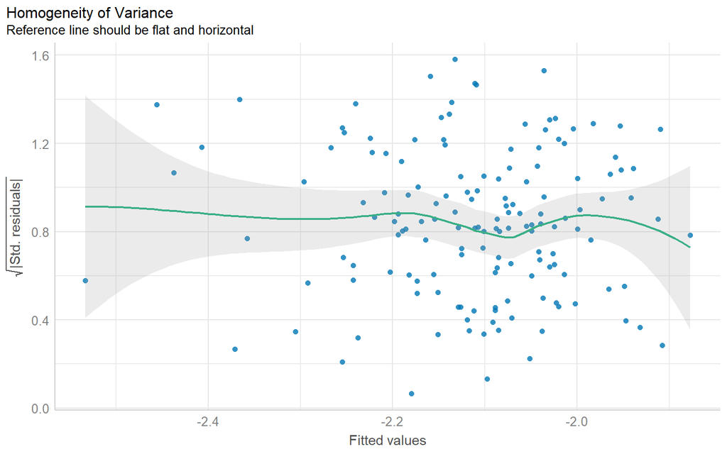

```r
library(performance)

plot(check_heteroscedasticity(lineares.modell1))
```

Die Daten sollten gleichmäßig über die Linie verteilt sein und keine offensichtlichen Muster aufweisen.

## Normalität

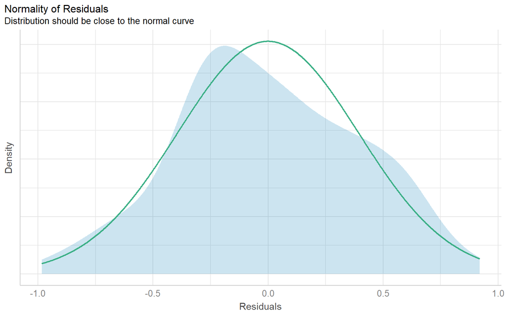

```r
library(performance)

plot(check_normality(lineares.modell1))
```

Die Verteilung der Residuen eines linearen Modells sollte einer Normalverteilung folgen.

## Unabhängigkeit

Unabhängigkeit kann nicht visuell überprüft werden. Es handelt sich um eine Annahme, die durch Untersuchung des Studiendesigns getestet wird.

# 05 Aufgaben

Erstelle nun Einfache Lineare Modelle für die folgenden $X$- und $Y$-Variablen. Sei dir bei jedem Modell darüber im Klaren, ob die vorhersagende Variable kontinuierlich oder kategorisch ist.

Aus `data_s`:

- `sDurLog` ~ `bsex`
- `sDurLog` ~ `typeOfS`
- `sDurLog` ~ `baseDurLog`
- `sDurLog` ~ `biphoneProbSumBin`
- `sDurLog` ~ `monoMultilingual`
- `sDurLog` ~ `pauseBin`
- `sDurLog` ~ `folType`
- `sDurLog` ~ `preC`

Aus `data_a`:

- `height` ~ `bsex`
- `height` ~ `hair`
- `height` ~ `eyes`

Aus `data_v`:

- `duration` ~ `vowel`
- `duration` ~ `structure`
- `duration` ~ `rate`

# 06 Extra

Schon fertig?

1. Besprecht in der Gruppe, ob euch Probleme bzgl. Einfacher Linearer Regression auffallen. (Tipp: *einfach* ist nicht immer besser)
2. Wie könnte man - ganz theoretisch - diese Probleme lösen? Denkt dabei abseits der Mathematik, hört auf eure Intuition.
3. Experimentiert und erstellt weitere Modelle, gerne auch zu den anderen Datensätzen aus dem `SfL` Package.